# Reproducible Research: Peer Assessment 1

## Loading and preprocessing the data

Unzip the file and read the csv file “activity.csv”

```r
library(dplyr)
unzip(zipfile = "activity.zip")
activity <- read.csv("activity.csv", header = TRUE , stringsAsFactors = FALSE )
```

Make the date culumn into a date type

```r
activity[,2] <- as.Date(activity[,2])
```

## What is mean total number of steps taken per day?

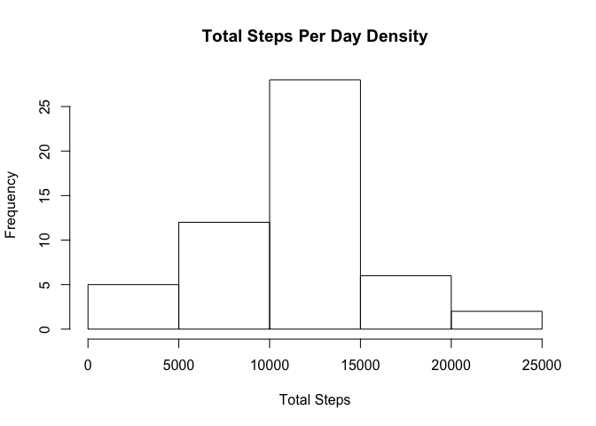

```r
gb <- group_by( activity[complete.cases(activity),] , date)
TotalSteps <- summarise(gb,total = sum(steps))
hist(TotalSteps$total, main="Total Steps Per Day Density",xlab = "Total Steps" )
```

```r
meanSteps <- mean(TotalSteps$total)
medianSteps <- median(TotalSteps$total)
```

For Total Steps per Day Density the mean is 10766.2 and the median is 10765

## What is the average daily activity pattern?

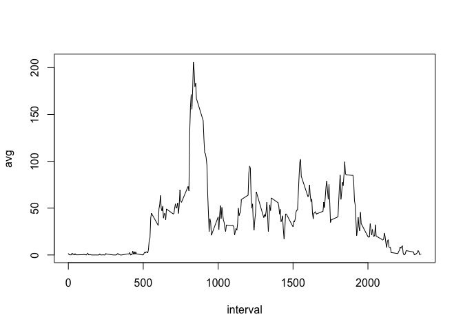

```r
gbi <- group_by( activity[complete.cases(activity),] , interval)
avgi <- summarise(gbi,avg = mean(steps))
maxInterval <- filter(avgi, avg == max(avgi$avg) )
plot(avgi,type = "l")
```

The Interval that contains the maximum number of steps (on average) is: 835

## Imputing missing values

```r
nas <- complete.cases(activity)
tb <- table(nas)
```

The number of rows with NA’s are: 2304

We will make a copy of the data and fill in NA vales

```r
activity_no_na <- activity
```

We will replace NA’s with the average steps for that interval

```r
activity_no_na[is.na(activity_no_na),1] <- avgi[ avgi$interval == activity_no_na[is.na(activity_no_na),3],2]
```

Plot the Histogram and calculate the mean and median

[figure not shown]

```r
TotalSteps <- summarise(gb,total = sum(steps))
hist(TotalSteps$total, main="Total Steps Per Day Density (no NA's)",xlab = "Total Steps" )
```

```r
meanSteps <- mean(TotalSteps$total)
medianSteps <- median(TotalSteps$total)
```

For Total Steps per Day Density the mean is 10766.2 and the median is 10765

Create a new factor variable in the dataset with two levels – “weekday” and “weekend” indicating whether a given date is a weekday or weekend day.

```r
activity_no_na$wk <- factor( (weekdays(as.Date(activity_no_na[,2] )) %in% c("Sunday","Saturday") ), labels = c("weekday","weekend"))
```

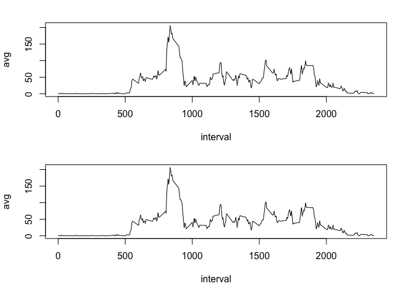

```r
par(mfrow = c(2, 1),mar=c(4,4,2,1))
plot(avgi,type = "l")

gbi_na <- group_by( activity_no_na[complete.cases(activity_no_na ),] , interval)
avgi_na <- summarise(gbi_na,avg = mean(steps))
maxInterval_na <- filter(avgi_na, avg == max(avgi_na$avg) )
plot(avgi_na,type = "l")
```